# Statistical inference with the GSS data

## Setup

### Load packages

```r
library(ggplot2)
library(dplyr)
library(statsr)
library(plyr)
```

### Load data

```r
load(file="gss.Rdata")
```

## Part 1: Data

While the GSS Survey initiative has been on-going for over 40 years, the current sampling and data collecion methods have evolved from numerous iterations and practices. In the early years (1972-1976), the GSS utilized a multi-stage area probability sample, down to the block level. Within these blocks, however, quota samping was used on the basis of three criteria: sex/gender, age and employment status. Prior to sampling at the block level, multi-stage sampling methods were stratified among their stages. The first, or primary sampling units were based upon the Standard Metropolitan Statistical Areas, as well as non-metropolitan counties. These sampling units were stratified by region, age, and race. The second stage was block groups and enumeration districts, which were stratified by race and income.

Naturally, such quota-based sampling does provide the opportunity for sample bias, though this has been somewhat negated by instructing interviewers to collet data or conduct interviews within precise parameters. Specifically, interviewers were told to only canvas areas for interview requests after 3:00 pm. However, this particular requirement does limit exposure to specific segments, including night or evening-shift workers. These types of person-to-person interviews were conducted up until 2001.

Fast-forward to the most recent survey (2014), the current GSS is drawn independently of English and Spanish-speaking persons, who are 18 years or older, and live in non-institutional arrangements within the United States. All of the previous years’ data (conducted at least bi-annually since 1972) are aggregated into a single response file, with data being collected during every period in February, March and April. The block quota sampling was abandoned after 1976. Since 2002, this data was collected via Computer-Assisted Personal Interviewing (CAPI).

The method of data collection is that of interviewing, or observational collection. With that being said, it is impossible to assume causality of any findings or analyses conducted with this data set: only correlation can be defined using this data.

## Part 2: Research question

With the presidential election nearly here, and the constant press surrounding candidates, it is extremely topical and relevant to hypothesize and analyze the political standings or affiliations of respondents. With over 40 years of data, it is of great interest to assess the basic demographical differences of the major political parties’ supporters, to get a better feel for the differences in opinion and lifestyles they may exhibit. Furthermore, it would be of great interest to utilize this dataset to answer our main research question: Are members of political parties similar in terms of there annual income? Or do any political party’s members exhibit a statistically significant difference in income?

## Part 3: Exploratory data analysis

We begin with a general distribution of our total sample’s income.

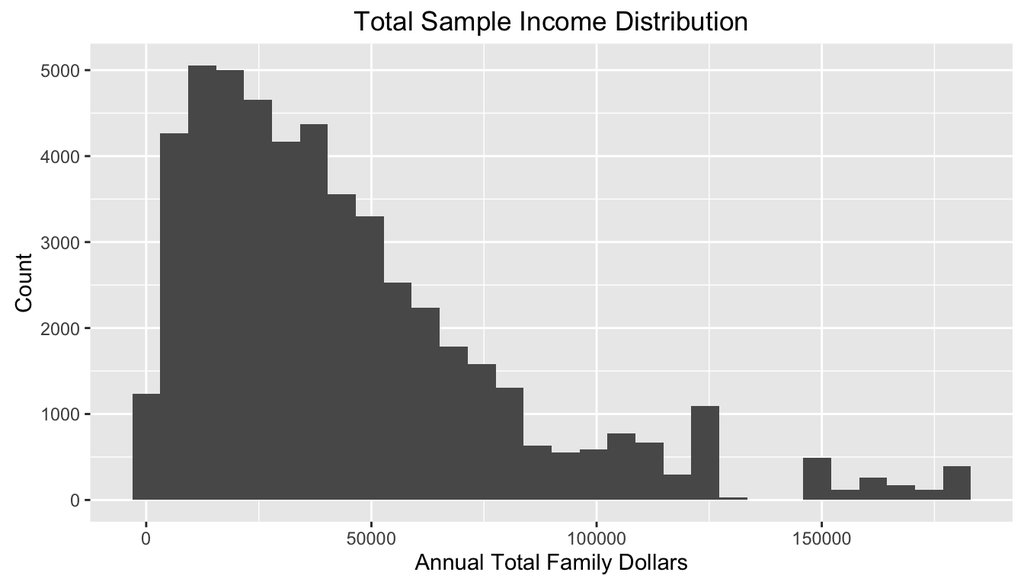

```r
ggplot(data = gss, aes(x = coninc)) +
  geom_histogram()+
  labs(title = "Total Sample Income Distribution", x = "Annual Total Family Dollars", y = "Count")
```

As well as a box plot to visually assess variance and distribution:

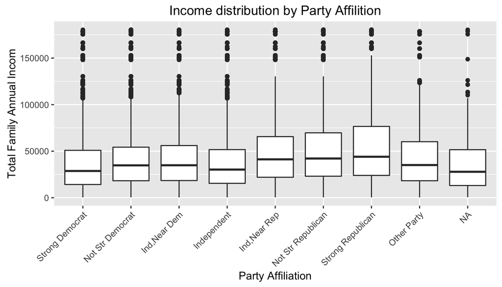

```r
ggplot(gss, aes(gss$partyid,gss$coninc)) +
  geom_boxplot()+
   labs(title = "Income distribution by Party Affilition", x = "Party Affiliation", y = "Total Family Annual Incom")+
  theme(axis.text.x = element_text(angle = 45, hjust = 1))
```

Furthermore, we can move forward with a graphical visualization of the frequency of party members in our dataset. A basic count-based bar chart shows the following:

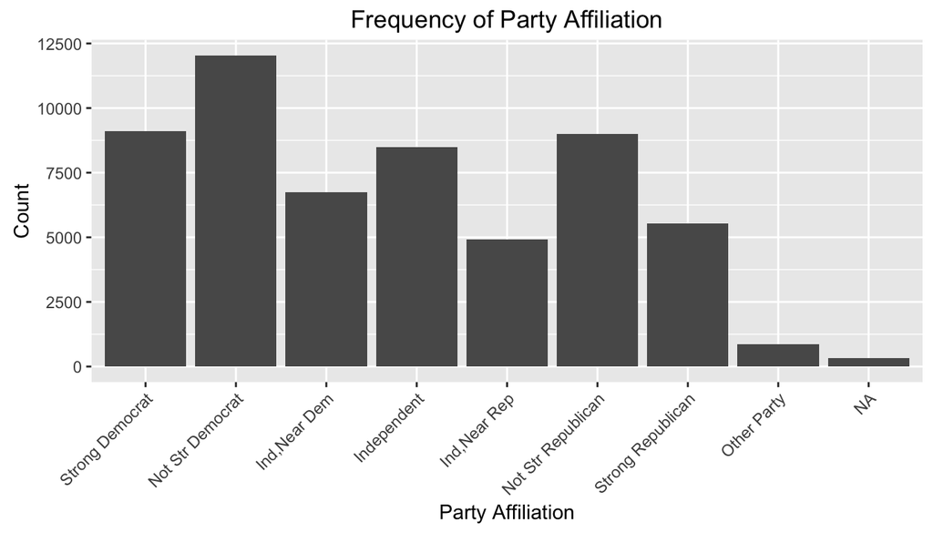

```r
ggplot(data = gss, aes(x = partyid)) +
  geom_bar()+
  labs(title = "Frequency of Party Affiliation", x = "Party Affiliation", y = "Count")+
  theme(axis.text.x = element_text(angle = 45, hjust = 1))
```

```r
strong_democrats <- gss %>%
  filter(partyid == "Strong Democrat")
not_str_democrats <- gss %>%
  filter(partyid == "Not Str Democrat")
strong_repub <- gss %>%
  filter(partyid == "Strong Republican")
not_str_repub <- gss %>%
  filter(partyid == "Not Str Republican")
indep <- gss %>%
  filter(partyid == "Independent")
indep_rep <- gss %>%
  filter(partyid == "Ind,Near Rep")
indep_dem <- gss %>%
  filter(partyid == "Ind,Near Dem")
other <- gss %>%
  filter(partyid == "Other Party")
```

```r
summary(gss$coninc)
```

```
##    Min. 1st Qu.  Median    Mean 3rd Qu.    Max.    NA's
##     383   18440   35600   44500   59540  180400    5829
```

```r
summary(indep$coninc)
```

```
##    Min. 1st Qu.  Median    Mean 3rd Qu.    Max.    NA's
##     383   15430   30230   38970   51700  180400    1276
```

```r
summary(indep_dem$coninc)
```

```
##    Min. 1st Qu.  Median    Mean 3rd Qu.    Max.    NA's
##     383   18460   34860   42830   56060  180400     542
```

```r
summary(indep_rep$coninc)
```

```
##    Min. 1st Qu.  Median    Mean 3rd Qu.    Max.    NA's
##     383   22000   41220   49180   65670  180400     396
```

```r
summary(not_str_repub$coninc)
```

```
##    Min. 1st Qu.  Median    Mean 3rd Qu.    Max.    NA's
##     402   23130   42130   51710   69720  180400     839
```

```r
summary(strong_repub$coninc)
```

```
##    Min. 1st Qu.  Median    Mean 3rd Qu.    Max.    NA's
##     383   23960   44010   55150   76600  180400     608
```

```r
summary(not_str_democrats$coninc)
```

```
##    Min. 1st Qu.  Median    Mean 3rd Qu.    Max.    NA's
##     383   18240   34770   41940   54290  180400    1045
```

```r
summary(strong_democrats$coninc)
```

```
##    Min. 1st Qu.  Median    Mean 3rd Qu.    Max.    NA's
##     383   14200   28720   37970   50930  180400     885
```

## Part 4: Inference

```r
anova <- aov(coninc ~ partyid, data=gss)
summary(anova)
```

```
##                Df    Sum Sq   Mean Sq F value Pr(>F)
## partyid         7 1.746e+12 2.495e+11   198.4 <2e-16 ***
## Residuals   51049 6.418e+13 1.257e+09
## ---
## Signif. codes:  0 '***' 0.001 '**' 0.01 '*' 0.05 '.' 0.1 ' ' 1
## 6004 observations deleted due to missingness
```

As we can see, our extremely low P-value (lower than our 0.05 significance level) signifies that we can reject the null hypothesis, and conclude that some of the party affiliations have different total family income means.